# Karthik S Bhat 21BCE7737

```python
import seaborn as sn
import pandas as pd
import numpy as np
```

```python
from matplotlib import pyplot as plt
```

```python
b=sn.load_dataset('car_crashes')
b.head(23)
```

|  | total | speeding | alcohol | not_distracted | no_previous | ins_premium | ins_losses | abbrev |
| --- | --- | --- | --- | --- | --- | --- | --- | --- |
| 0 | 18.8 | 7.332 | 5.640 | 18.048 | 15.040 | 784.55 | 145.08 | AL |
| 1 | 18.1 | 7.421 | 4.525 | 16.290 | 17.014 | 1053.48 | 133.93 | AK |
| 2 | 18.6 | 6.510 | 5.208 | 15.624 | 17.856 | 899.47 | 110.35 | AZ |
| 3 | 22.4 | 4.032 | 5.824 | 21.056 | 21.280 | 827.34 | 142.39 | AR |
| 4 | 12.0 | 4.200 | 3.360 | 10.920 | 10.680 | 878.41 | 165.63 | CA |
| 5 | 13.6 | 5.032 | 3.808 | 10.744 | 12.920 | 835.50 | 139.91 | CO |
| 6 | 10.8 | 4.968 | 3.888 | 9.396 | 8.856 | 1068.73 | 167.02 | CT |
| 7 | 16.2 | 6.156 | 4.860 | 14.094 | 16.038 | 1137.87 | 151.48 | DE |
| 8 | 5.9 | 2.006 | 1.593 | 5.900 | 5.900 | 1273.89 | 136.05 | DC |
| 9 | 17.9 | 3.759 | 5.191 | 16.468 | 16.826 | 1160.13 | 144.18 | FL |
| 10 | 15.6 | 2.964 | 3.900 | 14.820 | 14.508 | 913.15 | 142.80 | GA |
| 11 | 17.5 | 9.450 | 7.175 | 14.350 | 15.225 | 861.18 | 120.92 | HI |
| 12 | 15.3 | 5.508 | 4.437 | 13.005 | 14.994 | 641.96 | 82.75 | ID |
| 13 | 12.8 | 4.608 | 4.352 | 12.032 | 12.288 | 803.11 | 139.15 | IL |
| 14 | 14.5 | 3.625 | 4.205 | 13.775 | 13.775 | 710.46 | 108.92 | IN |
| 15 | 15.7 | 2.669 | 3.925 | 15.229 | 13.659 | 649.06 | 114.47 | IA |
| 16 | 17.8 | 4.806 | 4.272 | 13.706 | 15.130 | 780.45 | 133.80 | KS |
| 17 | 21.4 | 4.066 | 4.922 | 16.692 | 16.264 | 872.51 | 137.13 | KY |
| 18 | 20.5 | 7.175 | 6.765 | 14.965 | 20.090 | 1281.55 | 194.78 | LA |
| 19 | 15.1 | 5.738 | 4.530 | 13.137 | 12.684 | 661.88 | 96.57 | ME |
| 20 | 12.5 | 4.250 | 4.000 | 8.875 | 12.375 | 1048.78 | 192.70 | MD |
| 21 | 8.2 | 1.886 | 2.870 | 7.134 | 6.560 | 1011.14 | 135.63 | MA |
| 22 | 14.1 | 3.384 | 3.948 | 13.395 | 10.857 | 1110.61 | 152.26 | MI |

# Based on the data above, we will plot graph of abbrev (States) against the other attributes

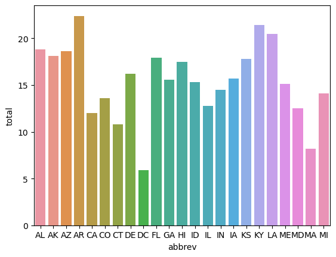

```python
df=b.head(23)
total_crashes_cmp_states=sn.barplot(x="abbrev",y="total", data=df)
```

## For readability sake we have taken 23 rows, In the above plot we can see that state 'AR' had the highest accident rate compared to other states and state 'DC' had lowest.

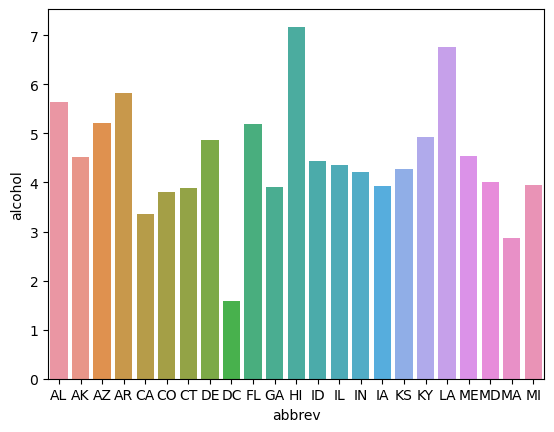

```python
alcohol_states=sn.barplot(x="abbrev",y="alcohol",data=df)
```

## From the above plot is infered that the state 'HI' has the highest rate of alcohol related accidents, here too 'DC' has the lowest accident rate.

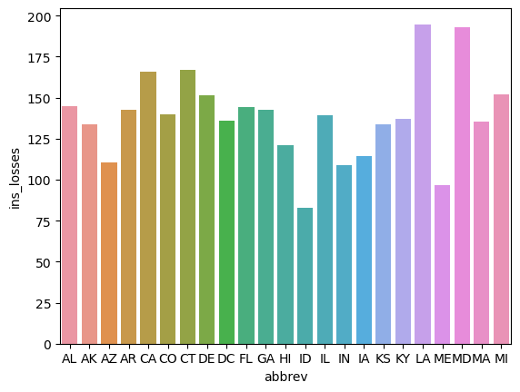

```python
total_ins_losses=sn.barplot(x="abbrev",y="ins_losses",data=df)
```

## From the plot it is infered that 'LA' has the highest rate of loss for insurance companies per insured driver and 'ID' generates least loss.

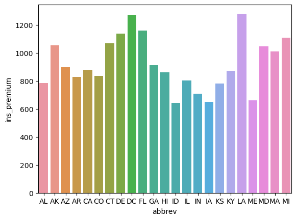

```python
ins_premium_state=sn.barplot(x="abbrev",y="ins_premium",data=df)
```

## Here we see that although DC has one of the lowest accident rates (from graph 1), They and 'LA' pay very high premiums compared to other states.

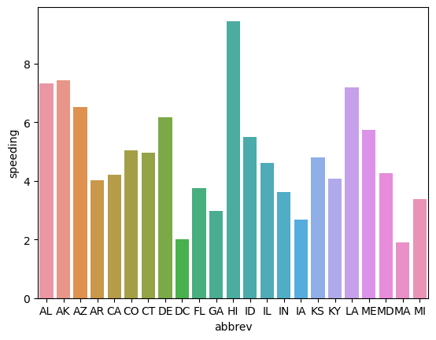

```python
speeding_accidents=sn.barplot(x="abbrev",y="speeding",data=df)
```

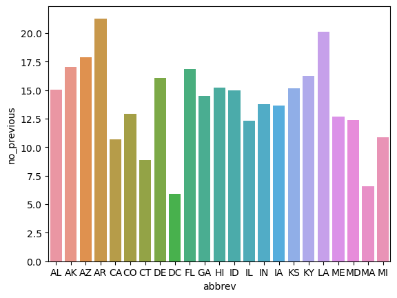

```python
no_previous_states=sn.barplot(x="abbrev",y="no_previous",data=df)
```

## From the above, we can say that 'AR' state has the highest rate of accidents among people who have never had an accident before.

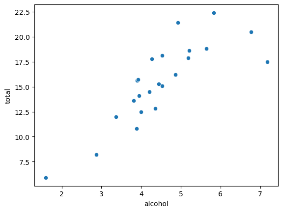

```python
alcohol_vs_total=sn.scatterplot(x="alcohol",y="total", data=df)
```

## From the above scatterplot we can say that total rate of accidents is strongly related to drunken driving as the plot appears to show a positive correlation between drunken driving and accident rate

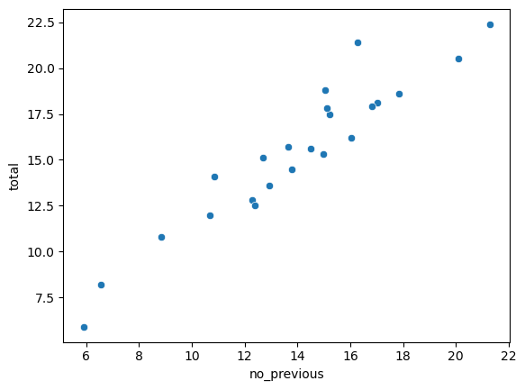

```python
n_prev_vs_total=sn.scatterplot(x="no_previous",y="total", data=df)
```

## Here we can see a positive correlation between total rate of accidents and no_previous. What this basically means is that the higher rate of accidents is highly correlated to Drivers who have NEVER had an accident before

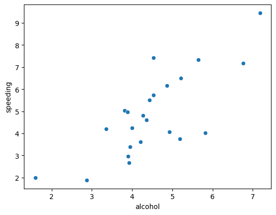

```python
speeding_vs_alcohol=sn.scatterplot(x="alcohol",y= "speeding" , data=df)
```

## The correlation is positive but does not appear to be very strong but, it does indicate that speeding is caused due to influence of alcohol

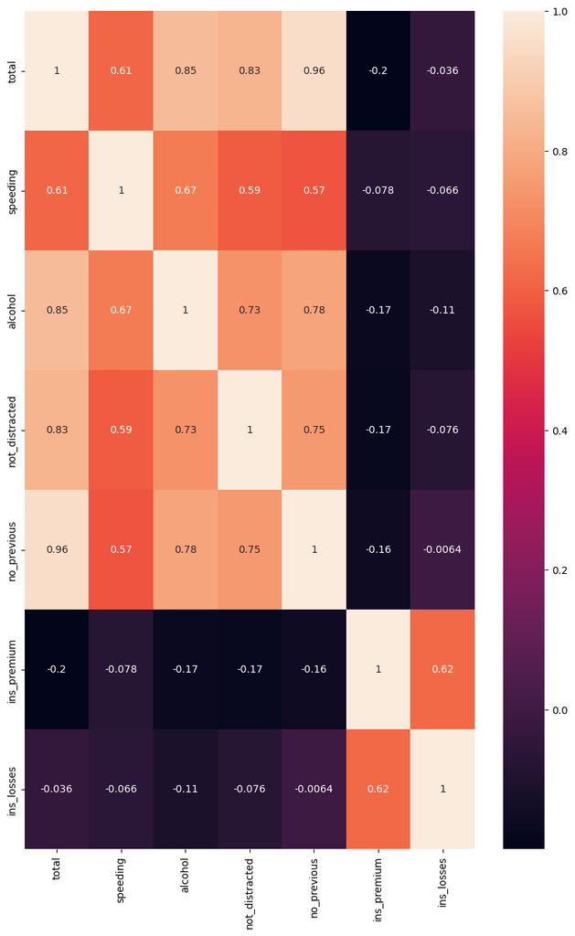

```python
corr=b.corr()
plt.subplots(figsize=(10,15))
sn.heatmap(corr,annot=True)
```

# From the correlation matrix, we can make a few inferences:

## 2. Speeding accidents are caused mostly due to drunken driving (alcohol) followed by non distracted drivers and first time offenders.

## 3. Non distracted driver related accidents are mostly caused by people who have never had an accident before.

## 4. First time offenders (no_previous) related accidents are mostly due to drunken driving (alcohol) followed by non distracted drivers.